# Regional Income Growth and House Price Dynamics in the Netherlands

# Part 3 - Quantifying

## 3.1 Data cleaning

```r
mean(dataset$percollege)
```

```
## [1] 18.27274
```

Please use a separate ‘R block’ of code for each type of cleaning. So, e.g. one for missing values, a new one for removing unnecessary variables etc.

## 3.5 Visualize sub-population variation

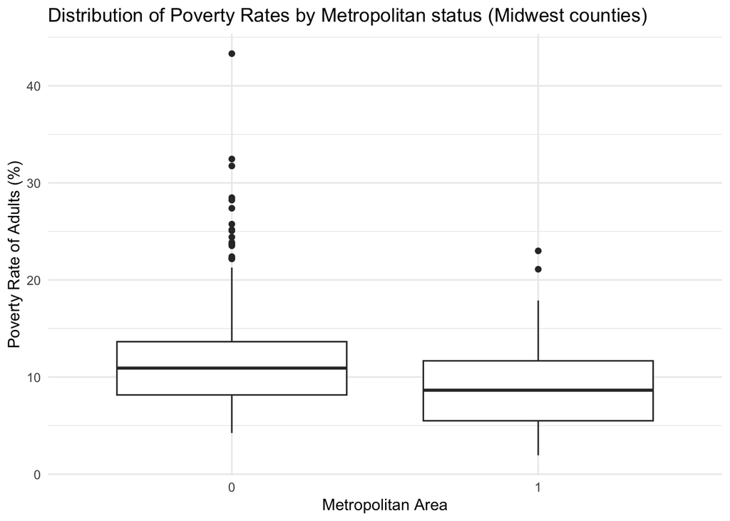

```r
dataset$inmetro <- dataset$inmetro %>% as.factor()
# Boxplot of poverty rate by state using the 'midwest' dataset
ggplot(dataset, aes(x = inmetro, y = percadultpoverty)) +
  geom_boxplot() +
  labs(
    title = "Distribution of Poverty Rates by Metropolitan status (Midwest counties)",
    x = "Metropolitan Area",
    y = "Poverty Rate of Adults (%)"
  ) +
  theme_minimal() +
  theme(
    legend.position = "right"
  )
```

## 3.6 Event analysis

# Part 4 - Discussion

## 4.1 Discuss your findings

# Part 5 - Reproducibility

## 5.2 Reference list

Use APA referencing throughout your document.